```r
activity <- read.csv("C:/Users/10012186/Documents/work/repdata_data_activity/activity.csv")
```

## **Loading the packages**

```r
library(dplyr)
library(plyr)
```

```r
library(ggplot2)
library(lattice)
```

## **Processing the data, creating new columns**

```r
activity$day <- weekdays(as.Date(activity$date))
activity$DateTime <- as.POSIXct(activity$date, format="%Y-%m-%d")
```

# Cleaning the data

## **Pulling the data without NAs**

```r
clean_data <- activity[!is.na(activity$steps),]
```

# *What is the mean total of steps taken per day?*

## **Calculate the total steps taken**

```r
total_steps <- aggregate(activity$steps~activity$date, FUN=sum)
colnames(total_steps) <- c("Date", "Number of Steps")
```

## **Create a histogram of the total steps per day**

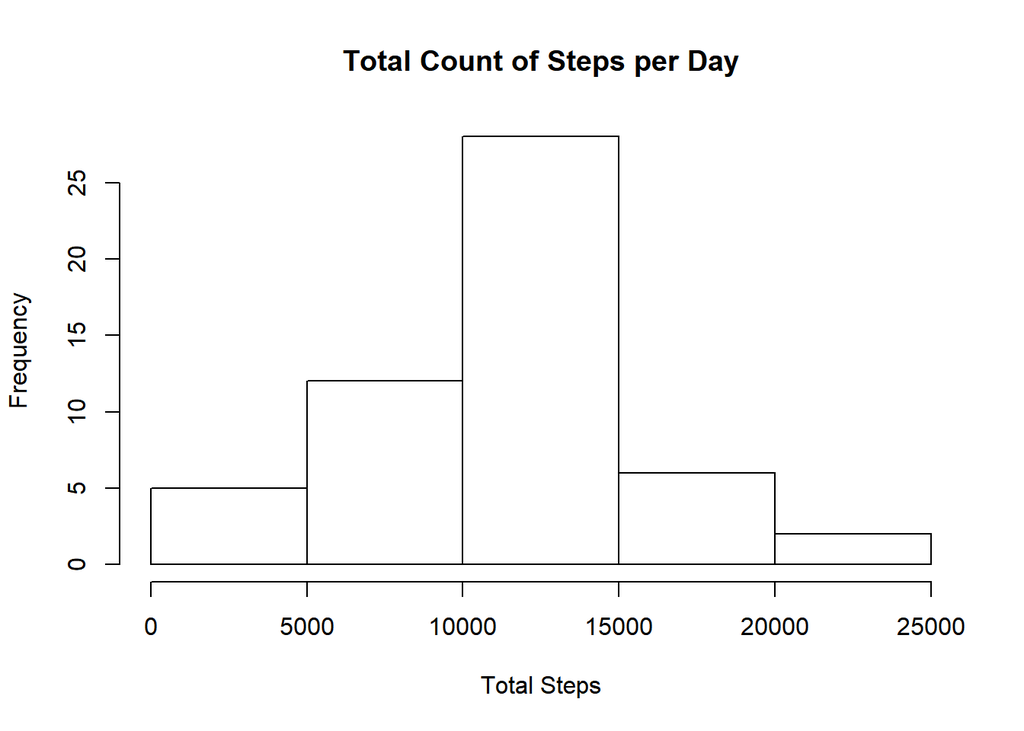

```r
hist(total_steps$`Number of Steps`, breaks = 5, xlab="Total Steps", main = "Total Count of Steps per Day")
```

## Mean of steps

```r
as.integer(mean(total_steps$`Number of Steps`))
```

```
## [1] 10766
```

## Median of Steps

```r
as.integer(median(total_steps$`Number of Steps`))
```

```
## [1] 10765
```

### The average number of steps taken per day was 10766

### The median number of steps taken per day was 10765

# *What is the average daily activity pattern?*

```r
steps_per_interval <- ddply(clean_data, .(interval), summarize, Avg=mean(steps))
```

## **Create time series plot of average number of steps per interval**

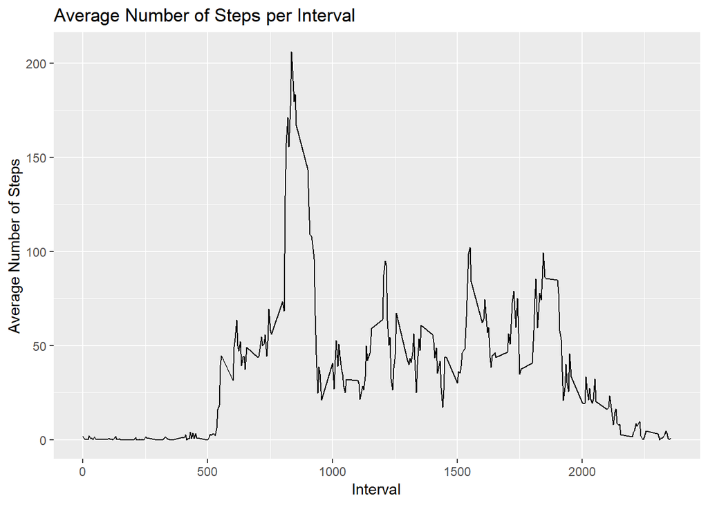

```r
steps_per_5min <- ggplot(steps_per_interval, aes(x=interval, y=Avg), xlab="Interval", ylab="Average Number of Steps")
steps_per_5min + geom_line()+xlab("Interval")+ylab("Average Number of Steps")+ggtitle("Average Number of Steps per Interval")
```

# Which 5-minute Interval, on average across all the days in the dataset, contains the maximum number of steps?

## Maximum steps by interval

```r
max_steps <- max(steps_per_interval$Avg)
```

## Which interval contains the maximum average number of steps?

```r
steps_per_interval[steps_per_interval$Avg==max_steps,1]
```

```
## [1] 835
```

### The maximum number of steps for each 5 minute interval is 206 steps

# *Imputing the missing values*

## **Calculate and report the total number of missing values in the dataset**

### Number of total NAs in the original data set

```r
nrow(activity[is.na(activity$steps),])
```

```
## [1] 2304
```

### The total number of rows with NA steps is 2304

## **Replace missing values**

### Create the average number of steps per weekday and interval

```r
new_avg_steps <- ddply(clean_data, .(interval, day), summarize, Avg=mean(steps))
```

### Create dataset with just NAs

```r
NA_data <- activity[is.na(activity$steps),]
```

### Merge NA_data with new_avg_steps

```r
merged_data <- merge(NA_data, new_avg_steps, by=c("interval", "day"))
```

### Re-order the new table in the same format as the clean dataset

```r
merged_data2 <- merged_data[,c(6,4,1,2,5)]
colnames(merged_data2) <- c("steps", "date", "interval", "day", "DateTime")
```

### Merge the NA data and the non-NA data together

```r
new_merge_data <- rbind(clean_data, merged_data2)
```

## Create sum of steps per date to compare with step 1

```r
total_steps2 <- aggregate(new_merge_data$steps~new_merge_data$date, FUN=sum, )
colnames(total_steps2)<- c("Date", "Steps")
```

## Mean of Steps with NA data taken care of

```r
as.integer(mean(total_steps2$Steps))
```

```
## [1] 10821
```

## Median of Steps with NA data taken care of

```r
as.integer(median(total_steps2$Steps))
```

```
## [1] 11015
```

## **Creating the histogram of total steps per day, categorized by data set to show impact**

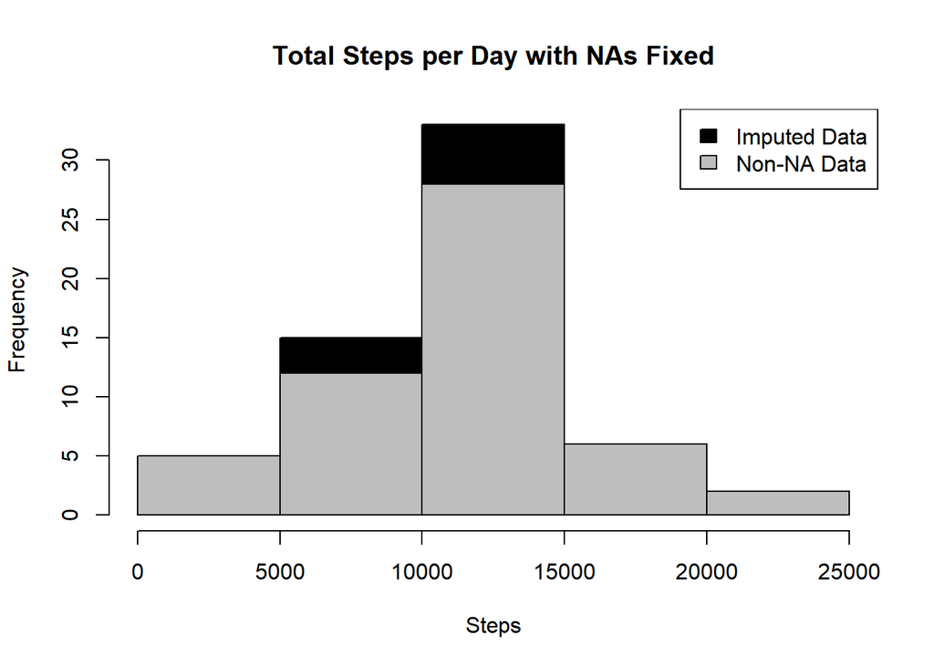

```r
hist(total_steps2$Steps, breaks=5, xlab="Steps", main = "Total Steps per Day with NAs Fixed", col="Black")
hist(total_steps$`Number of Steps`, breaks=5, xlab="Steps", main = "Total Steps per Day with NAs Fixed", col="Grey", add=T)
legend("topright", c("Imputed Data", "Non-NA Data"), fill=c("black", "grey") )
```

### The new median of the imputed data is 11015 steps compared to the old median of 10765 steps.

### That creates a difference of 250 steps for the median.

## However, the overall shape of the distribution has not changed.

## **Create new category based on the days of the week**

```r
new_merge_data$DayCategory <- ifelse(new_merge_data$day %in% c("Saturday", "Sunday"), "Weekend", "Weekday")
```

### Summarize data by interval and type of day

```r
intervalTable2 <- ddply(new_merge_data, .(interval, DayCategory), summarize, Avg = mean(steps))
```

### Plot data in a panel plot

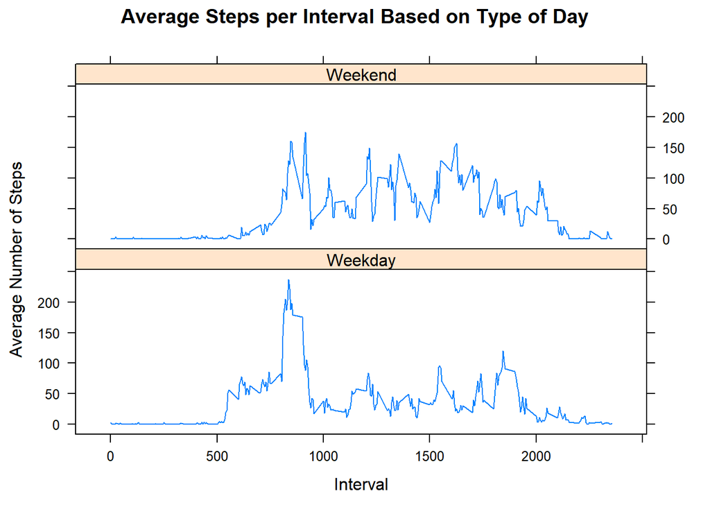

```r
xyplot(Avg~interval|DayCategory, data=intervalTable2, type="l",  layout = c(1,2),
       main="Average Steps per Interval Based on Type of Day",
       ylab="Average Number of Steps", xlab="Interval")
```

### The step activity trends are different on what day it occured.